# Introduction to single-cell RNA-seq analysis

Quality Control - Practical

## 0.1 Introduction

In the demonstration we performed QC and filtering of 4 of our sample, one from each of our sample groups. For this practical we would like you to perform QC and filtering on the full dataset.

## 0.2 Load the sample metadata

```r
sampleinfo <- read_tsv("Data/sample_sheet.tsv")
```

## 0.3 Load the data

In order to load the CellRanger data for all of the samples, you will first need to create a named vector of the paths to the filtered count matrix folders called `list_of_files` and then use this in the `Read10X` command.

**Hint**

The paths to `filtered_feature_bc_matrix` directories for each sample can be constructed using the **Sample** column as:

Data/CellRanger_Outputs/*Sample*/outs/filtered_feature_bc_matrix

You will need to use a function such as `str_c` or `paste`

The names of the vector will determine the identifer used in the cell barcodes, this should be the sample name as in the **SampleName** column of the sample sheet.

As Seurat V5 no longer supports parallelisation with `future` this step may take a couple of minutes.

**Answer**

```r
samples <- sampleinfo$Sample
list_of_files <- str_c("Data/CellRanger_Outputs/",
                       samples,
                       "/outs/filtered_feature_bc_matrix")
names(list_of_files) <- sampleinfo$SampleName
list_of_files
```

```
##                                                          ETV6RUNX1-1
## "Data/CellRanger_Outputs/SRR9264343/outs/filtered_feature_bc_matrix"
##                                                          ETV6RUNX1-2
## "Data/CellRanger_Outputs/SRR9264344/outs/filtered_feature_bc_matrix"
##                                                          ETV6RUNX1-3
## "Data/CellRanger_Outputs/SRR9264345/outs/filtered_feature_bc_matrix"
##                                                          ETV6RUNX1-4
## "Data/CellRanger_Outputs/SRR9264346/outs/filtered_feature_bc_matrix"
##                                                                HHD-1
## "Data/CellRanger_Outputs/SRR9264347/outs/filtered_feature_bc_matrix"
##                                                                HHD-2
## "Data/CellRanger_Outputs/SRR9264348/outs/filtered_feature_bc_matrix"
##                                                               PRET-1
## "Data/CellRanger_Outputs/SRR9264349/outs/filtered_feature_bc_matrix"
##                                                               PRET-2
## "Data/CellRanger_Outputs/SRR9264350/outs/filtered_feature_bc_matrix"
##                                                              PBMMC-1
## "Data/CellRanger_Outputs/SRR9264351/outs/filtered_feature_bc_matrix"
##                                                              PBMMC-2
## "Data/CellRanger_Outputs/SRR9264353/outs/filtered_feature_bc_matrix"
##                                                              PBMMC-3
## "Data/CellRanger_Outputs/SRR9264354/outs/filtered_feature_bc_matrix"
```

```r
expression_matrix <- Read10X(data.dir = list_of_files)
seurat_object = CreateSeuratObject(counts = expression_matrix, min.cells = 1)
seurat_object
```

```
## An object of class Seurat
## 33869 features across 53476 samples within 1 assay
## Active assay: RNA (33869 features, 0 variable features)
##  1 layer present: counts
```

## 0.4 Check samples and modify the metadata

The first thing we will do is to adjust the metadata as we did in the demonstration to include the sample name and sample group which we obtain from the `orig.ident` column.

```r
temp_meta.data <- seurat_object@meta.data %>%
  rownames_to_column("Cell") %>%
  separate(col = "orig.ident", into = c("SampleGroup"), sep = "-", remove = FALSE) %>%
  mutate(SampleName = orig.ident) %>%
  column_to_rownames("Cell")

seurat_object@meta.data <- temp_meta.data
head(seurat_object@meta.data)
```

```
##                                 orig.ident SampleGroup nCount_RNA nFeature_RNA
## ETV6RUNX1-1_AAACCTGAGACTTTCG-1 ETV6RUNX1-1   ETV6RUNX1       8354         2935
## ETV6RUNX1-1_AAACCTGGTCTTCAAG-1 ETV6RUNX1-1   ETV6RUNX1      14974         4341
## ETV6RUNX1-1_AAACCTGGTGCAACTT-1 ETV6RUNX1-1   ETV6RUNX1       1566          931
## ETV6RUNX1-1_AAACCTGGTGTTGAGG-1 ETV6RUNX1-1   ETV6RUNX1      10468         3636
## ETV6RUNX1-1_AAACCTGTCCCAAGTA-1 ETV6RUNX1-1   ETV6RUNX1      10437         3340
## ETV6RUNX1-1_AAACCTGTCGAATGCT-1 ETV6RUNX1-1   ETV6RUNX1       2453         1392
##                                 SampleName
## ETV6RUNX1-1_AAACCTGAGACTTTCG-1 ETV6RUNX1-1
## ETV6RUNX1-1_AAACCTGGTCTTCAAG-1 ETV6RUNX1-1
## ETV6RUNX1-1_AAACCTGGTGCAACTT-1 ETV6RUNX1-1
## ETV6RUNX1-1_AAACCTGGTGTTGAGG-1 ETV6RUNX1-1
## ETV6RUNX1-1_AAACCTGTCCCAAGTA-1 ETV6RUNX1-1
## ETV6RUNX1-1_AAACCTGTCGAATGCT-1 ETV6RUNX1-1
```

## 0.5 Add the mitochondrial percentages to the meta data

```r
seurat_object[["percent.mt"]] <- PercentageFeatureSet(seurat_object, pattern = "^MT-")
```

# 1 Explore QC metric distribution

Before moving on to do the actual cell filtering, it is always a good idea to explore the distribution of the metrics across the droplets.

Use the `Seurat` function `VlnPlot` to generate plots showing the distributions of the total number of UMIs, the number of genes detected and percentage of UMIs aligned to mitochondrial genes across all cells for each sample.

This time we will use the cols argument and a vector of colours to make it easier to tell each sample group apart.

The code for plotting the total number of UMIs is shown below. You will also need to plot the the number of genes detected and percentage of UMIs aligned to mitochondrial.

```r
colours <- c("cyan3","cyan3","cyan3","cyan3","darkgoldenrod1","darkgoldenrod1","blue","blue","blue","lightgreen","lightgreen")

VlnPlot(seurat_object,
        features = c("nCount_RNA"),
        cols = colours,
        layer = "counts",
        pt.size=0) +
  ggtitle("Total count of UMIs")
```

[output not shown]

**Answer**

```r
VlnPlot(seurat_object,
        features = c("nFeature_RNA"),
        cols = colours,
        layer = "counts",
        pt.size=0) +
  ggtitle("Detected Features")
```

[output not shown]

```r
VlnPlot(seurat_object,
        features = c("percent.mt"),
        cols = colours,
        layer = "counts",
        pt.size=0) +
  ggtitle("Mitochondrial Percentage")
```

[output not shown]

# 2 Identification of low-quality cells with adaptive thresholds

With these samples we have three possible “batch” levels at which we could run adaptive filtering. We could apply the filtering across all samples together (i.e. no `batch`), we could apply it by sample group (ETV6-RUNX1, HHD, PBMMC, PRE-T), or we could apply it per sample.

How many cells will be removed from the data set if we used sample group? And do you think this is a reasonable method to choose? How would you decide?

**Hint**

Use the code from the demonstration to set thresholds at a `SampleGroup` level rather than for every sample. Change the filtering of the metadata to get only the cells you want.

**Answer**

```r
metadata <- seurat_object@meta.data

E_keep_cells <- metadata %>%
  filter(SampleGroup == "ETV6RUNX1") %>%
  filter(nFeature_RNA > (median(nFeature_RNA) - 2 * mad(nFeature_RNA)),
         nCount_RNA > (median(nCount_RNA) - 2 * mad(nCount_RNA)),
         percent.mt < (median(percent.mt) + 2 * mad(percent.mt))) %>%
  rownames_to_column("Cell") %>%
  pull(Cell)

H_keep_cells <- metadata %>%
  filter(SampleGroup == "HHD") %>%
  filter(nFeature_RNA > (median(nFeature_RNA) - 2 * mad(nFeature_RNA)),
         nCount_RNA > (median(nCount_RNA) - 2 * mad(nCount_RNA)),
         percent.mt < (median(percent.mt) + 2 * mad(percent.mt))) %>%
  rownames_to_column("Cell") %>%
  pull(Cell)

PR_keep_cells <- metadata %>%
  filter(SampleGroup == "PRET") %>%
  filter(nFeature_RNA > (median(nFeature_RNA) - 2 * mad(nFeature_RNA)),
         nCount_RNA > (median(nCount_RNA) - 2 * mad(nCount_RNA)),
         percent.mt < (median(percent.mt) + 2 * mad(percent.mt))) %>%
  rownames_to_column("Cell") %>%
  pull(Cell)

PB_keep_cells <- metadata %>%
  filter(SampleGroup == "PBMMC") %>%
  filter(nFeature_RNA > (median(nFeature_RNA) - 2 * mad(nFeature_RNA)),
         nCount_RNA > (median(nCount_RNA) - 2 * mad(nCount_RNA)),
         percent.mt < (median(percent.mt) + 2 * mad(percent.mt))) %>%
  rownames_to_column("Cell") %>%
  pull(Cell)

all_keep_cells <- c(E_keep_cells, H_keep_cells, PR_keep_cells, PB_keep_cells)

53476 - length(all_keep_cells)
```

```
## [1] 6013
```

In total 6013 cells will be removed from the dataset.

It is clear that there are significantly different distribution profiles between samples in the same group. Noticeably the distribution profiles for the two HDD samples are quite different. For this reason it may be prudent to apply the adaptive filtering to each sample independently.

We can help ourselves decide by drawing out the plots. We have set the Seurat plot’s points to 0 to remove them but added our own geom_point from `ggplot2` to display the cells we are keeping and removing in different colours.

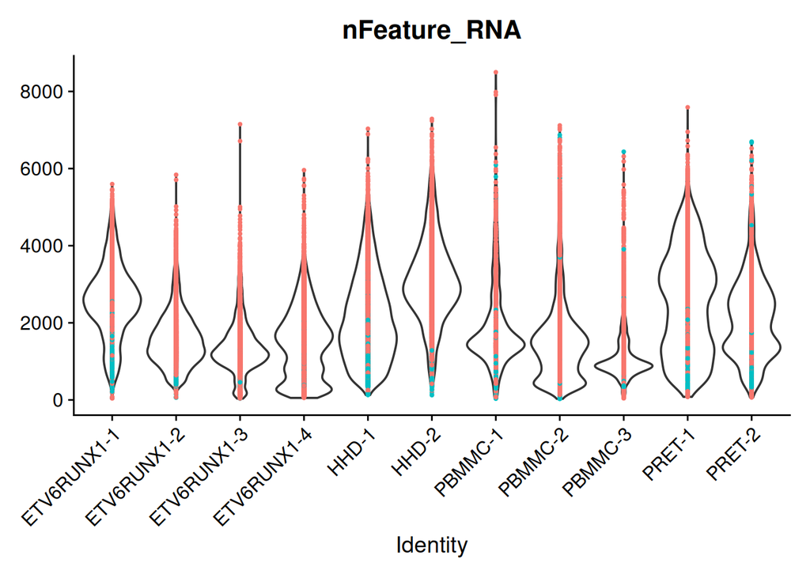

```r
new_metadata <- metadata %>%
  rownames_to_column("Cell") %>%
  mutate(Keep = ifelse(Cell %in% all_keep_cells, "Keep", "Remove")) %>%
  column_to_rownames("Cell")

seurat_object@meta.data <- new_metadata

VlnPlot(seurat_object,
        features = c("nFeature_RNA"),
        cols = rep(c("white"), each = 11),
        layer = "counts",
        pt.size=0) +
  geom_point(mapping = aes(color = seurat_object@meta.data$Keep), size = 0.5) + theme(legend.position = 'none')
```

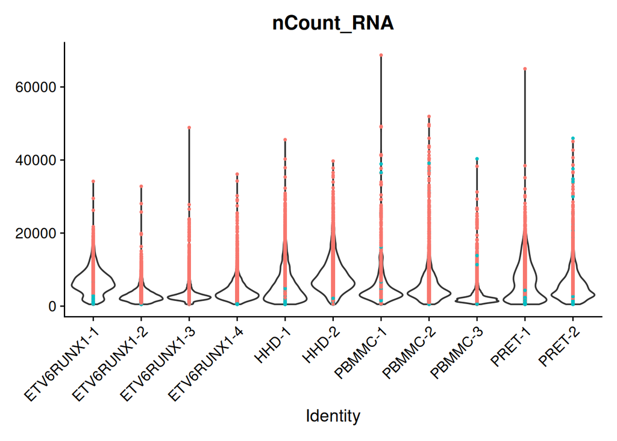

```r
VlnPlot(seurat_object,
        features = c("nCount_RNA"),
        cols = rep(c("white"), each = 11),
        layer = "counts",
        pt.size=0) +
  geom_point(mapping = aes(color = seurat_object@meta.data$Keep), size = 0.5) + theme(legend.position = 'none')
```

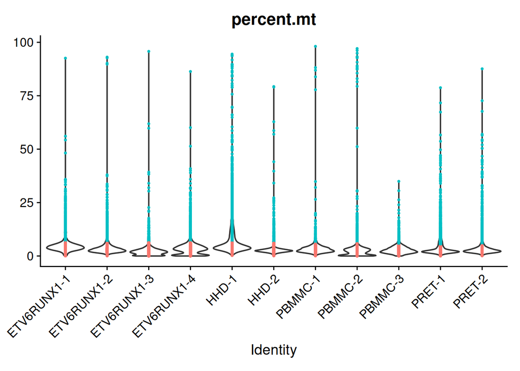

```r
VlnPlot(seurat_object,
        features = c("percent.mt"),
        cols = rep(c("white"), each = 11),
        layer = "counts",
        pt.size=0) +
  geom_point(mapping = aes(color = seurat_object@meta.data$Keep), size = 0.5) + theme(legend.position = 'none')
```

If we are happy with this filtering we can remove them from the Seurat object.

```r
filtered_seurat_object <- subset(seurat_object, cells = all_keep_cells)
```